# Elsevier 2022 SDG mapping

# General to all SDGs

## Introduction

The United Nations Sustainable Development Goals (SDGs) challenge the global community to build a world where no one is left behind.

Since 2018, Elsevier has generated SDG search queries to help researchers and institutions track and demonstrate progress toward the SDG targets. In the past 3 years, these queries, along with the university’s own data and evidence supporting progress and contributions to the particular SDG outside of research-based metrics, are used for the THE Impact Rankings.

## Method

For 2022, this SDG uses the exact same search query and ML algorithm as the Elsevier 2021 SDG mapping. [Full details of the 2021 methodology are available on Digital Commons Data.](https://elsevier.digitalcommonsdata.com/datasets/9sxdykm8s4/4)

# [SDG 7 - Ensure access to affordable, reliable, sustainable and modern energy for all](https://sdgs.un.org/goals/goal7)

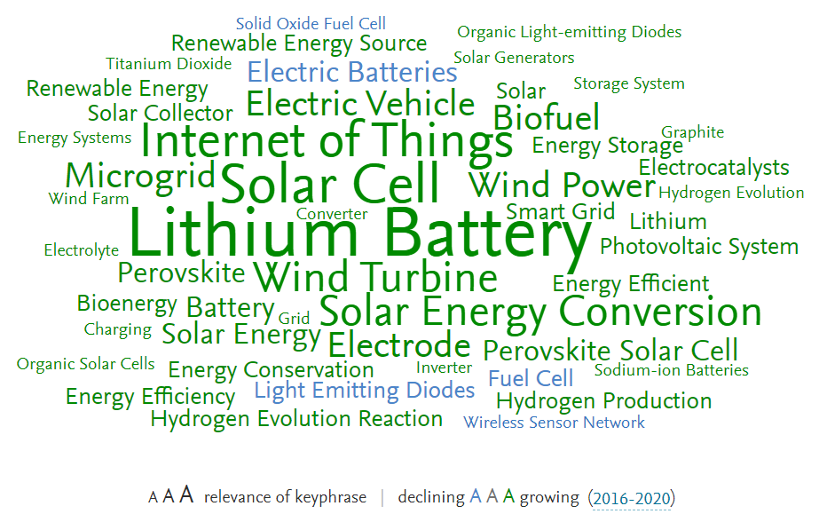

Explore this wordcloud plus the most active contributors on the [SciVal SDG site](https://scival.com/sdg)

## Query

Below is the full search query used for this SDG. We’ve broken it down by each query component. Use the + and – to concatenate the different bracket levels.

(

(

(

(

TITLE-ABS("dmfc") OR TITLE-ABS("dmfcs")

)

AND TITLE-ABS

(

"methanol"

)

)

OR

(

(

AUTHKEY("dmfc") OR AUTHKEY("dmfcs")

)

AND AUTHKEY

(

"methanol"

)

)

OR

(

(

(TITLE-ABS("thermal storage") AND TITLE-ABS("geothermal")) OR (AUTHKEY("thermal storage") AND AUTHKEY("geothermal")) OR (TITLE-ABS("thermal energy") AND TITLE-ABS("geothermal") AND TITLE-ABS("reservoir*")) OR (AUTHKEY("thermal energy") AND AUTHKEY("geothermal") AND AUTHKEY("reservoir*")) OR (TITLE-ABS("thermal energy") AND TITLE-ABS("geotherm system*")) OR (AUTHKEY("thermal energy") AND AUTHKEY("geotherm system*")) OR (TITLE-ABS("thermal energy") AND TITLE-ABS("geothermal gradient")) OR (AUTHKEY("thermal energy") AND AUTHKEY("geothermal gradient")) OR (TITLE-ABS("Steam extraction") AND TITLE-ABS("geotherm*")) OR (AUTHKEY("Steam extraction") AND AUTHKEY("geotherm*")) OR (TITLE-ABS("geothermal power") OR TITLE-ABS("geothermic power")) OR (AUTHKEY("geothermal power") OR AUTHKEY("geothermic power")) OR TITLE-ABS("geotherm plant*") OR AUTHKEY("geotherm plant*") OR TITLE-ABS("geotherm powerplant*") OR AUTHKEY("geotherm powerplant*") OR TITLE-ABS("Geyser Power Plant*") OR AUTHKEY("Geyser Power Plant*") OR TITLE-ABS("geotherm heat plant*") OR AUTHKEY("geotherm heat plant*") OR (TITLE-ABS("geotherm energ*") AND NOT (TITLE-ABS("geotherm energ recover*"))) OR (AUTHKEY("geotherm energ*") AND NOT (AUTHKEY("geotherm energ recover*"))) OR (TITLE-ABS("geotherm*") AND (TITLE-ABS("geoenergy") OR TITLE-ABS("geo-energy"))) OR (AUTHKEY("geotherm*") AND (AUTHKEY("geoenergy") OR AUTHKEY("geo-energy"))) OR TITLE-ABS("geotherm resource*") OR AUTHKEY("geotherm resource*") OR TITLE-ABS("geotherm electric*") OR AUTHKEY("geotherm electric*") OR TITLE-ABS("geotherm project*") OR AUTHKEY("geotherm project*") OR TITLE-ABS("geotherm industr*") OR AUTHKEY("geotherm industr*") OR TITLE-ABS("geotherm facilit*") OR AUTHKEY("geotherm facilit*") OR TITLE-ABS("geotherm generation") OR AUTHKEY("geotherm generation") OR TITLE-ABS("geotherm exploration*") OR AUTHKEY("geotherm exploration*") OR (TITLE-ABS("geotherm") AND TITLE-ABS("exploitation")) OR (AUTHKEY("geotherm") AND AUTHKEY("exploitation")) OR TITLE-ABS("geotherm development*") OR AUTHKEY("geotherm development*") OR TITLE-ABS("geotherm prospect*") OR AUTHKEY("geotherm prospect*") OR TITLE-ABS("geotherm production") OR AUTHKEY("geotherm production") OR TITLE-ABS("geotherm application*") OR AUTHKEY("geotherm application*") OR TITLE-ABS("geothermal potential*") OR AUTHKEY("geothermal potential*") OR TITLE-ABS("Geotherm Technolog*") OR AUTHKEY("Geotherm Technolog*") OR TITLE-ABS("Geothermal Techni*") OR AUTHKEY("Geothermal Techni*") OR TITLE-ABS("geotherm well*") OR AUTHKEY("geotherm well*") OR (TITLE-ABS("production well*") AND TITLE-ABS("geotherm*")) OR (AUTHKEY("production well*") AND AUTHKEY("geotherm*")) OR (TITLE-ABS("injection well*") AND TITLE-ABS("geotherm*")) OR (AUTHKEY("injection well*") AND AUTHKEY("geotherm*")) OR (TITLE-ABS("geothermal") AND TITLE-ABS("injection*") AND TITLE-ABS("reservoir*")) OR (AUTHKEY("geothermal") AND AUTHKEY("injection*") AND AUTHKEY("reservoir*")) OR (TITLE-ABS("geothermal") AND TITLE-ABS("injection*") AND TITLE-ABS("well*")) OR (AUTHKEY("geothermal") AND AUTHKEY("injection*") AND AUTHKEY("well*")) OR (TITLE-ABS("reinjection") AND TITLE-ABS("geotherm*")) OR (AUTHKEY("reinjection") AND AUTHKEY("geotherm*")) OR TITLE-ABS("geothermal reservoir*") OR AUTHKEY("geothermal reservoir*") OR (TITLE-ABS("dry steam") AND TITLE-ABS("geotherm*")) OR (AUTHKEY("dry steam") AND AUTHKEY("geotherm*")) OR TITLE-ABS("Dry steam plant*") OR AUTHKEY("Dry steam plant*") OR TITLE-ABS("Dry steam power") OR AUTHKEY("Dry steam power") OR (TITLE-ABS("flash steam") AND TITLE-ABS("geotherm*")) OR (AUTHKEY("flash steam") AND AUTHKEY("geotherm*")) OR TITLE-ABS("flash steam plant*") OR AUTHKEY("flash steam plant*") OR TITLE-ABS("flash steam power") OR AUTHKEY("flash steam power") OR (TITLE-ABS("drill*") AND TITLE-ABS("geothermal")) OR (AUTHKEY("drill*") AND AUTHKEY("geothermal")) OR TITLE-ABS("geotherm pipeline*") OR AUTHKEY("geotherm pipeline*") OR (TITLE-ABS("steam pipeline*") AND TITLE-ABS("geotherm*")) OR (AUTHKEY("steam pipeline*") AND AUTHKEY("geotherm*")) OR (TITLE-ABS("pipe network*") AND TITLE-ABS("geotherm*")) OR (AUTHKEY("pipe network*") AND AUTHKEY("geotherm*")) OR TITLE-ABS("geotherm installation*") OR AUTHKEY("geotherm installation*") OR TITLE-ABS("geotherm turbine*") OR AUTHKEY("geotherm turbine*") OR TITLE-ABS("geotherm gas turbine*") OR AUTHKEY("geotherm gas turbine*") OR TITLE-ABS("geotherm steam power plant*") OR AUTHKEY("geotherm steam power plant*") OR TITLE-ABS("geotherm steam turbine*") OR AUTHKEY("geotherm steam turbine*") OR (TITLE-ABS("binary cycle*") AND TITLE-ABS("geotherm*")) OR (AUTHKEY("binary cycle*") AND AUTHKEY("geotherm*")) OR TITLE-ABS("binary cycle power plant*") OR AUTHKEY("binary cycle power plant*") OR TITLE-ABS("binary cycle plant*") OR AUTHKEY("binary cycle plant*") OR TITLE-ABS("binary plant*") OR AUTHKEY("binary plant*") OR TITLE-ABS("binary power plant*") OR AUTHKEY("binary power plant*") OR TITLE-ABS("geothermal binary plant*") OR AUTHKEY("geothermal binary plant*") OR TITLE-ABS("binary geothermal") OR AUTHKEY("binary geothermal") OR (TITLE-ABS("geotherm*") AND TITLE-ABS("district heating*")) OR (AUTHKEY("geotherm*") AND AUTHKEY("district heating*")) OR (TITLE-ABS("geotherm*") AND TITLE-ABS("district energy")) OR (AUTHKEY("geotherm*") AND AUTHKEY("district energy")) OR (TITLE-ABS("geotherm*") AND TITLE-ABS("heating and cooling")) OR (AUTHKEY("geotherm*") AND AUTHKEY("heating and cooling")) OR (TITLE-ABS("geotherm*") AND TITLE-ABS("heat pump*")) OR (AUTHKEY("geotherm*") AND AUTHKEY("heat pump*")) OR TITLE-ABS("geotherm pump*") OR AUTHKEY("geotherm pump*") OR (TITLE-ABS("geotherm*") AND TITLE-ABS("heat exchange*")) OR (AUTHKEY("geotherm*") AND AUTHKEY("heat exchange*")) OR TITLE-ABS("geotherm exchange*") OR AUTHKEY("geotherm exchange*") OR TITLE-ABS("ground heat exchanger") OR AUTHKEY("ground heat exchanger") OR TITLE-ABS("ground source heat system*") OR AUTHKEY("ground source heat system*") OR TITLE-ABS("ground source heat pump*") OR AUTHKEY("ground source heat pump*") OR (TITLE-ABS("underground source heat*") OR TITLE-ABS("under-ground source heat*")) OR (AUTHKEY("underground source heat*") OR AUTHKEY("under-ground source heat*")) OR TITLE-ABS("borehole heat exchange*") OR AUTHKEY("borehole heat exchange*") OR TITLE-ABS("downhole heat exchange*") OR AUTHKEY("downhole heat exchange*") OR TITLE-ABS("Shallow geothermal") OR AUTHKEY("Shallow geothermal") OR (TITLE-ABS("geothermal heating") AND TITLE-ABS("energy")) OR (AUTHKEY("geothermal heating") AND AUTHKEY("energy")) OR (TITLE-ABS("geothermal heat") AND TITLE-ABS("energy")) OR (AUTHKEY("geothermal heat") AND AUTHKEY("energy")) OR (TITLE-ABS("heat storage") AND TITLE-ABS("geotherm*")) OR (AUTHKEY("heat storage") AND AUTHKEY("geotherm*")) OR (TITLE-ABS("geotherm*") AND TITLE-ABS("heat extraction*")) OR (AUTHKEY("geotherm*") AND AUTHKEY("heat extraction*")) OR (TITLE-ABS("geotherm*") AND TITLE-ABS("kalina cycle*")) OR (AUTHKEY("geotherm*") AND AUTHKEY("kalina cycle*")) OR (TITLE-ABS("geotherm*") AND TITLE-ABS("rankine")) OR (AUTHKEY("geotherm*") AND AUTHKEY("rankine")) OR TITLE-ABS("geotherm cool*") OR AUTHKEY("geotherm cool*") OR (TITLE-ABS("energy piles") AND TITLE-ABS("geotherm*")) OR (AUTHKEY("energy piles") AND AUTHKEY("geotherm*")) OR TITLE-ABS("geothermal tracer*") OR AUTHKEY("geothermal tracer*") OR TITLE-ABS("Multi-borehole Circulating System*") OR AUTHKEY("Multi-borehole Circulating System*") OR TITLE-ABS("Enhanced geotherm system*") OR AUTHKEY("Enhanced geotherm system*") OR (TITLE-ABS("EGS") AND TITLE-ABS("geotherm*")) OR (AUTHKEY("EGS") AND AUTHKEY("geotherm*")) OR TITLE-ABS("engineered geothermal") OR AUTHKEY("engineered geothermal") OR TITLE-ABS("stimulated geothermal") OR AUTHKEY("stimulated geothermal") OR TITLE-ABS("Hot Dry Rock*") OR AUTHKEY("Hot Dry Rock*") OR TITLE-ABS("HDR/HWR") OR AUTHKEY("HDR/HWR") OR (TITLE-ABS("HDR") AND TITLE-ABS("geotherm*")) OR (AUTHKEY("HDR") AND AUTHKEY("geotherm*")) OR (TITLE-ABS("H.D.R.") AND TITLE-ABS("geotherm*")) OR (AUTHKEY("H.D.R.") AND AUTHKEY("geotherm*")) OR (TITLE-ABS("HDR") AND TITLE-ABS("Reservoir*")) OR (AUTHKEY("HDR") AND AUTHKEY("Reservoir*")) OR (TITLE-ABS("H.D.R") AND TITLE-ABS("Reservoir*")) OR (AUTHKEY("H.D.R") AND AUTHKEY("Reservoir*")) OR TITLE-ABS("hot fractured rock") OR AUTHKEY("hot fractured rock") OR TITLE-ABS("heat mining") OR AUTHKEY("heat mining") OR (TITLE-ABS("electricity") AND TITLE-ABS("geotherm*")) OR (AUTHKEY("electricity") AND AUTHKEY("geotherm*")) OR ((TITLE-ABS("thermoelectric*") OR TITLE-ABS("thermo-electric*")) AND TITLE-ABS("geotherm*")) OR ((AUTHKEY("thermoelectric*") OR AUTHKEY("thermo-electric*")) AND AUTHKEY("geotherm*")) OR (TITLE-ABS("geotherm*") AND TITLE-ABS("energy") AND TITLE-ABS("heat*")) OR (AUTHKEY("geotherm*") AND AUTHKEY("energy") AND AUTHKEY("heat*")) OR TITLE-ABS("hydrogeothermal") OR AUTHKEY("hydrogeothermal")

)

AND NOT

(

((TITLE-ABS("contamina*") OR TITLE-ABS("geotherm emission*") OR (TITLE-ABS("environmental impact*") AND TITLE-ABS("pollution")) OR TITLE-ABS("environmental impact of geothermal") OR TITLE-ABS("Bioaccumulation") OR TITLE-ABS("geothermal air pollution") OR (TITLE-ABS("Impact of geothermal") AND TITLE-ABS("pollution")) OR TITLE-ABS("pollution of geothermal") OR TITLE-ABS("Boron pollution") OR (TITLE-ABS("Boron") AND TITLE-ABS("removal")) OR TITLE-ABS("Treatment of geothermal") OR TITLE-ABS("Biomonitor*") OR TITLE-ABS("treatment of waste") OR TITLE-ABS("treatment of wastewater") OR TITLE-ABS("waste treatment") OR TITLE-ABS("wastewater treatment") OR TITLE-ABS("thallium") OR TITLE-ABS("toxic metals") OR TITLE-ABS("phytotoxicity") OR (TITLE-ABS("Arsenic") AND TITLE-ABS("pollution")) OR (TITLE-ABS("Arsenic") AND TITLE-ABS("removal")) OR TITLE-ABS("Hydrochemistry") OR TITLE-ABS("silica ceramics") OR TITLE-ABS("Environmental effects of mass") OR TITLE-ABS("environmental aspects of geothermal")) OR (AUTHKEY("contamina*") OR AUTHKEY("geotherm emission*") OR (AUTHKEY("environmental impact*") AND AUTHKEY("pollution")) OR AUTHKEY("environmental impact of geothermal") OR AUTHKEY("Bioaccumulation") OR AUTHKEY("geothermal air pollution") OR (AUTHKEY("Impact of geothermal") AND AUTHKEY("pollution")) OR AUTHKEY("pollution of geothermal") OR AUTHKEY("Boron pollution") OR (AUTHKEY("Boron") AND AUTHKEY("removal")) OR AUTHKEY("Treatment of geothermal") OR AUTHKEY("Biomonitor*") OR AUTHKEY("treatment of waste") OR AUTHKEY("treatment of wastewater") OR AUTHKEY("waste treatment") OR AUTHKEY("wastewater treatment") OR AUTHKEY("thallium") OR AUTHKEY("toxic metals") OR AUTHKEY("phytotoxicity") OR (AUTHKEY("Arsenic") AND AUTHKEY("pollution")) OR (AUTHKEY("Arsenic") AND AUTHKEY("removal")) OR AUTHKEY("Hydrochemistry") OR AUTHKEY("silica ceramics") OR AUTHKEY("Environmental effects of mass") OR AUTHKEY("environmental aspects of geothermal")))

)

)

OR

(

(

((TITLE-ABS("solar") AND TITLE-ABS("renewable energy")) AND NOT ((TITLE-ABS("satellite") OR TITLE-ABS("solar mission") OR TITLE-ABS("national renewable energy")))) OR ((AUTHKEY("solar") AND AUTHKEY("renewable energy")) AND NOT ((AUTHKEY("satellite") OR AUTHKEY("solar mission") OR AUTHKEY("national renewable energy")))) OR (TITLE-ABS("solar") AND TITLE-ABS("clean energy")) OR (AUTHKEY("solar") AND AUTHKEY("clean energy")) OR (TITLE-ABS("solar power") AND NOT (TITLE-ABS("space solar power"))) OR (AUTHKEY("solar power") AND NOT (AUTHKEY("space solar power"))) OR (TITLE-ABS("solar-powered") AND NOT (TITLE-ABS("space solar powered"))) OR (AUTHKEY("solar-powered") AND NOT (AUTHKEY("space solar powered"))) OR ((TITLE-ABS("CSP plants") AND TITLE-ABS("solar")) OR (TITLE-ABS("CSP plant") AND TITLE-ABS("solar"))) OR ((AUTHKEY("CSP plants") AND AUTHKEY("solar")) OR (AUTHKEY("CSP plant") AND AUTHKEY("solar"))) OR TITLE-ABS("concentrated solar thermal") OR AUTHKEY("concentrated solar thermal") OR TITLE-ABS("solar plant*") OR AUTHKEY("solar plant*") OR TITLE-ABS("solar park*") OR AUTHKEY("solar park*") OR (TITLE-ABS("solar farm") OR TITLE-ABS("solar farms")) OR (AUTHKEY("solar farm") OR AUTHKEY("solar farms")) OR TITLE-ABS("solar concentrating power") OR AUTHKEY("solar concentrating power") OR TITLE-ABS("solar energy conver*") OR AUTHKEY("solar energy conver*") OR TITLE-ABS("solar energy application*") OR AUTHKEY("solar energy application*") OR TITLE-ABS("solar energy project*") OR AUTHKEY("solar energy project*") OR TITLE-ABS("solar energy resource*") OR AUTHKEY("solar energy resource*") OR TITLE-ABS("solar energy plant*") OR AUTHKEY("solar energy plant*") OR TITLE-ABS("solar energy system*") OR AUTHKEY("solar energy system*") OR TITLE-ABS("solar energy collector*") OR AUTHKEY("solar energy collector*") OR TITLE-ABS("solar energy concentrator*") OR AUTHKEY("solar energy concentrator*") OR TITLE-ABS("solar thermal") OR AUTHKEY("solar thermal") OR (TITLE-ABS("solar thermal power plants") OR TITLE-ABS("solar thermal power plant")) OR (AUTHKEY("solar thermal power plants") OR AUTHKEY("solar thermal power plant")) OR (TITLE-ABS("STE plant") OR TITLE-ABS("STE plants")) OR (AUTHKEY("STE plant") OR AUTHKEY("STE plants")) OR TITLE-ABS("solar thermal energy") OR AUTHKEY("solar thermal energy") OR TITLE-ABS("Solar thermal Electric") OR AUTHKEY("Solar thermal Electric") OR TITLE-ABS("Solar Thermal Electricity") OR AUTHKEY("Solar Thermal Electricity") OR TITLE-ABS("solar thermal collector*") OR AUTHKEY("solar thermal collector*") OR TITLE-ABS("thermal solar collector*") OR AUTHKEY("thermal solar collector*") OR TITLE-ABS("Solar thermionic") OR AUTHKEY("Solar thermionic") OR TITLE-ABS("Solar updraft") OR AUTHKEY("Solar updraft") OR TITLE-ABS("heliostat*") OR AUTHKEY("heliostat*") OR (TITLE-ABS("solar chimney") AND TITLE-ABS("plants")) OR (AUTHKEY("solar chimney") AND AUTHKEY("plants")) OR (TITLE-ABS("solar chimney") AND TITLE-ABS("plant")) OR (AUTHKEY("solar chimney") AND AUTHKEY("plant")) OR TITLE-ABS("solar furnace*") OR AUTHKEY("solar furnace*") OR TITLE-ABS("solar powered Stirling") OR AUTHKEY("solar powered Stirling") OR (TITLE-ABS("Stirling") AND TITLE-ABS("solar")) OR (AUTHKEY("Stirling") AND AUTHKEY("solar")) OR (TITLE-ABS("Stirling") AND TITLE-ABS("dish")) OR (AUTHKEY("Stirling") AND AUTHKEY("dish")) OR (TITLE-ABS("rankine") AND TITLE-ABS("solar")) OR (AUTHKEY("rankine") AND AUTHKEY("solar")) OR TITLE-ABS("solar cavity receiver") OR AUTHKEY("solar cavity receiver") OR TITLE-ABS("solar dish") OR AUTHKEY("solar dish") OR TITLE-ABS("dish concentrator*") OR AUTHKEY("dish concentrator*") OR TITLE-ABS("dish solar collector*") OR AUTHKEY("dish solar collector*") OR ((TITLE-ABS("parabolic dish") AND TITLE-ABS("solar")) AND NOT ((TITLE-ABS("antenna*") OR TITLE-ABS("radio")))) OR ((AUTHKEY("parabolic dish") AND AUTHKEY("solar")) AND NOT ((AUTHKEY("antenna*") OR AUTHKEY("radio")))) OR TITLE-ABS("parabolic dish collector*") OR AUTHKEY("parabolic dish collector*") OR (TITLE-ABS("solar panel*") AND NOT ((TITLE-ABS("space") OR TITLE-ABS("rover") OR TITLE-ABS("ISS") OR TITLE-ABS("satellite")))) OR (AUTHKEY("solar panel*") AND NOT ((AUTHKEY("space") OR AUTHKEY("rover") OR AUTHKEY("ISS") OR AUTHKEY("satellite")))) OR (TITLE-ABS("PV panel*") AND NOT ((TITLE-ABS("space") OR TITLE-ABS("rover") OR TITLE-ABS("ISS") OR TITLE-ABS("satellite")))) OR (AUTHKEY("PV panel*") AND NOT ((AUTHKEY("space") OR AUTHKEY("rover") OR AUTHKEY("ISS") OR AUTHKEY("satellite")))) OR TITLE-ABS("solar track*") OR AUTHKEY("solar track*") OR (TITLE-ABS("solar cell*") AND NOT ((TITLE-ABS("cosmology") OR TITLE-ABS("cosmic")))) OR (AUTHKEY("solar cell*") AND NOT ((AUTHKEY("cosmology") OR AUTHKEY("cosmic")))) OR (TITLE-ABS("parabolic concentrator*") AND TITLE-ABS("solar")) OR (AUTHKEY("parabolic concentrator*") AND AUTHKEY("solar")) OR (TITLE-ABS("Parabolic trough") OR TITLE-ABS("Parabolic troughs")) OR (AUTHKEY("Parabolic trough") OR AUTHKEY("Parabolic troughs")) OR TITLE-ABS("Trough concentrator*") OR AUTHKEY("Trough concentrator*") OR TITLE-ABS("solar trough") OR AUTHKEY("solar trough") OR TITLE-ABS("parabolic solar concentrators") OR AUTHKEY("parabolic solar concentrators") OR TITLE-ABS("solar parabolic concentrator") OR AUTHKEY("solar parabolic concentrator") OR TITLE-ABS("solar parabolic collector*") OR AUTHKEY("solar parabolic collector*") OR (TITLE-ABS("focus collectors") OR TITLE-ABS("focus collector")) OR (AUTHKEY("focus collectors") OR AUTHKEY("focus collector")) OR (TITLE-ABS("Trough") AND TITLE-ABS("solar collector*")) OR (AUTHKEY("Trough") AND AUTHKEY("solar collector*")) OR TITLE-ABS("fresnel collector*") OR AUTHKEY("fresnel collector*") OR (TITLE-ABS("fresnel lens*") AND TITLE-ABS("solar")) OR (AUTHKEY("fresnel lens*") AND AUTHKEY("solar")) OR TITLE-ABS("Molten Salt Central Receiver") OR AUTHKEY("Molten Salt Central Receiver") OR (TITLE-ABS("Molten Salt") AND TITLE-ABS("solar")) OR (AUTHKEY("Molten Salt") AND AUTHKEY("solar")) OR (TITLE-ABS("Solar Beam Down Tower") OR TITLE-ABS("Solar Beam Down Towers")) OR (AUTHKEY("Solar Beam Down Tower") OR AUTHKEY("Solar Beam Down Towers")) OR (TITLE-ABS("Solar-driven Gas Turbines") OR TITLE-ABS("Solar-driven Gas Turbine")) OR (AUTHKEY("Solar-driven Gas Turbines") OR AUTHKEY("Solar-driven Gas Turbine")) OR (TITLE-ABS("Solar Gas Turbines") OR TITLE-ABS("Solar Gas Turbine")) OR (AUTHKEY("Solar Gas Turbines") OR AUTHKEY("Solar Gas Turbine")) OR (TITLE-ABS("solar combined cycle power plants") OR TITLE-ABS("solar combined cycle power plant")) OR (AUTHKEY("solar combined cycle power plants") OR AUTHKEY("solar combined cycle power plant")) OR TITLE-ABS("Integrated Solar Combined Cycle") OR AUTHKEY("Integrated Solar Combined Cycle") OR TITLE-ABS("photovoltaic*") OR AUTHKEY("photovoltaic*") OR TITLE-ABS("thermophotovoltaic*") OR AUTHKEY("thermophotovoltaic*") OR TITLE-ABS("PV cell*") OR AUTHKEY("PV cell*") OR TITLE-ABS("PV batter*") OR AUTHKEY("PV batter*") OR TITLE-ABS("PV energy") OR AUTHKEY("PV energy") OR TITLE-ABS("PV power") OR AUTHKEY("PV power") OR TITLE-ABS("PV hybrid*") OR AUTHKEY("PV hybrid*") OR ((TITLE-ABS("multicrystalline silicon") OR TITLE-ABS("multi-crystalline silicon")) AND (TITLE-ABS("wafer*") OR TITLE-ABS("cell") OR TITLE-ABS("cells") OR TITLE-ABS("solar") OR TITLE-ABS("PV"))) OR ((AUTHKEY("multicrystalline silicon") OR AUTHKEY("multi-crystalline silicon")) AND (AUTHKEY("wafer*") OR AUTHKEY("cell") OR AUTHKEY("cells") OR AUTHKEY("solar") OR AUTHKEY("PV"))) OR (TITLE-ABS("mc-Si cell") OR TITLE-ABS("mc-Si cells") OR TITLE-ABS("mc-Si solar")) OR (AUTHKEY("mc-Si cell") OR AUTHKEY("mc-Si cells") OR AUTHKEY("mc-Si solar")) OR (TITLE-ABS("mc-Si") AND TITLE-ABS("PV")) OR (AUTHKEY("mc-Si") AND AUTHKEY("PV")) OR ((TITLE-ABS("Polycrystalline silicon") OR TITLE-ABS("Poly-crystalline silicon")) AND TITLE-ABS("PV")) OR ((AUTHKEY("Polycrystalline silicon") OR AUTHKEY("Poly-crystalline silicon")) AND AUTHKEY("PV")) OR ((TITLE-ABS("Polycrystalline silicon") OR TITLE-ABS("Poly-crystalline silicon")) AND TITLE-ABS("solar")) OR ((AUTHKEY("Polycrystalline silicon") OR AUTHKEY("Poly-crystalline silicon")) AND AUTHKEY("solar")) OR ((TITLE-ABS("Monocrystalline silicon") OR TITLE-ABS("Mono-crystalline silicon")) AND TITLE-ABS("PV")) OR ((AUTHKEY("Monocrystalline silicon") OR AUTHKEY("Mono-crystalline silicon")) AND AUTHKEY("PV")) OR ((TITLE-ABS("Monocrystalline silicon") OR TITLE-ABS("Mono-crystalline silicon")) AND TITLE-ABS("solar")) OR ((AUTHKEY("Monocrystalline silicon") OR AUTHKEY("Mono-crystalline silicon")) AND AUTHKEY("solar")) OR (TITLE-ABS("Amorphous silicon") AND TITLE-ABS("solar")) OR (AUTHKEY("Amorphous silicon") AND AUTHKEY("solar")) OR (TITLE-ABS("Amorphous silicon") AND (TITLE-ABS("PV module") OR TITLE-ABS("PV modules"))) OR (AUTHKEY("Amorphous silicon") AND (AUTHKEY("PV module") OR AUTHKEY("PV modules"))) OR (TITLE-ABS("Amorphous silicon") AND TITLE-ABS("PV") AND TITLE-ABS("film")) OR (AUTHKEY("Amorphous silicon") AND AUTHKEY("PV") AND AUTHKEY("film")) OR TITLE-ABS("Amorphous silicon PV") OR AUTHKEY("Amorphous silicon PV") OR (TITLE-ABS("a-Si:H") AND TITLE-ABS("PV module")) OR (AUTHKEY("a-Si:H") AND AUTHKEY("PV module")) OR TITLE-ABS("organic PV") OR AUTHKEY("organic PV") OR TITLE-ABS("photoelectrochemical cell*") OR AUTHKEY("photoelectrochemical cell*") OR (TITLE-ABS("photo-electrochemical cells") OR TITLE-ABS("photo-electrochemical cell")) OR (AUTHKEY("photo-electrochemical cells") OR AUTHKEY("photo-electrochemical cell")) OR (TITLE-ABS("photoelectro-chemical cells") OR TITLE-ABS("photoelectro-chemical cell")) OR (AUTHKEY("photoelectro-chemical cells") OR AUTHKEY("photoelectro-chemical cell")) OR (TITLE-ABS("photo-electro-chemical cells") OR TITLE-ABS("photo-electro-chemical cell")) OR (AUTHKEY("photo-electro-chemical cells") OR AUTHKEY("photo-electro-chemical cell")) OR (TITLE-ABS("Maximum Power Point Tracking") AND TITLE-ABS("PV module")) OR (AUTHKEY("Maximum Power Point Tracking") AND AUTHKEY("PV module")) OR (TITLE-ABS("Maximum Power Point Tracking") AND TITLE-ABS("solar")) OR (AUTHKEY("Maximum Power Point Tracking") AND AUTHKEY("solar")) OR TITLE-ABS("solar calcination plant") OR AUTHKEY("solar calcination plant") OR TITLE-ABS("solar reforming") OR AUTHKEY("solar reforming") OR TITLE-ABS("solar powered ventilator*") OR AUTHKEY("solar powered ventilator*") OR TITLE-ABS("photo-electrochemical generation of hydrogen") OR AUTHKEY("photo-electrochemical generation of hydrogen") OR (TITLE-ABS("Desiccants") AND TITLE-ABS("solar energy")) OR (AUTHKEY("Desiccants") AND AUTHKEY("solar energy")) OR TITLE-ABS("photoelectrolysis water splitting") OR AUTHKEY("photoelectrolysis water splitting") OR TITLE-ABS("solar Domestic Hot Water") OR AUTHKEY("solar Domestic Hot Water") OR TITLE-ABS("solar water heat*") OR AUTHKEY("solar water heat*") OR TITLE-ABS("solar assisted heat*") OR AUTHKEY("solar assisted heat*") OR TITLE-ABS("solar heat system*") OR AUTHKEY("solar heat system*") OR TITLE-ABS("solar hot water") OR AUTHKEY("solar hot water") OR TITLE-ABS("solar chimney power plant") OR AUTHKEY("solar chimney power plant") OR TITLE-ABS("solar combisystems") OR AUTHKEY("solar combisystems") OR TITLE-ABS("solar chimney") OR AUTHKEY("solar chimney") OR TITLE-ABS("solar control coating*") OR AUTHKEY("solar control coating*") OR TITLE-ABS("solar absorbing surface*") OR AUTHKEY("solar absorbing surface*") OR TITLE-ABS("solar-grade silicon") OR AUTHKEY("solar-grade silicon") OR (TITLE-ABS("solar") AND TITLE-ABS("buildings") AND TITLE-ABS("glass")) OR (AUTHKEY("solar") AND AUTHKEY("buildings") AND AUTHKEY("glass")) OR TITLE-ABS("solar air heater*") OR AUTHKEY("solar air heater*") OR TITLE-ABS("solar desalination") OR AUTHKEY("solar desalination") OR TITLE-ABS("solar still*") OR AUTHKEY("solar still*") OR (TITLE-ABS("photocatalyst") AND TITLE-ABS("water splitting")) OR (AUTHKEY("photocatalyst") AND AUTHKEY("water splitting")) OR TITLE-ABS("solar and wind energy") OR AUTHKEY("solar and wind energy") OR TITLE-ABS("parabolic solar") OR AUTHKEY("parabolic solar") OR TITLE-ABS("solar collector*") OR AUTHKEY("solar collector*") OR TITLE-ABS("parabolic collector*") OR AUTHKEY("parabolic collector*") OR TITLE-ABS("domestic PV") OR AUTHKEY("domestic PV") OR TITLE-ABS("domestic solar") OR AUTHKEY("domestic solar") OR TITLE-ABS("solar cooker*") OR AUTHKEY("solar cooker*") OR TITLE-ABS("solar box cooker*") OR AUTHKEY("solar box cooker*") OR (TITLE-ABS("DSSC") AND TITLE-ABS("dye")) OR (AUTHKEY("DSSC") AND AUTHKEY("dye")) OR TITLE-ABS("thin-film solar") OR AUTHKEY("thin-film solar") OR (TITLE-ABS("pcbm") AND TITLE-ABS("solar")) OR (AUTHKEY("pcbm") AND AUTHKEY("solar")) OR (TITLE-ABS("cigs") AND TITLE-ABS("cell")) OR (AUTHKEY("cigs") AND AUTHKEY("cell")) OR (TITLE-ABS("Copper indium gallium selenide") AND TITLE-ABS("cell")) OR (AUTHKEY("Copper indium gallium selenide") AND AUTHKEY("cell")) OR (TITLE-ABS("pedot") AND TITLE-ABS("solar")) OR (AUTHKEY("pedot") AND AUTHKEY("solar")) OR (TITLE-ABS("Poly(3,4-ethylenedioxythiophene)") AND TITLE-ABS("solar")) OR (AUTHKEY("Poly(3,4-ethylenedioxythiophene)") AND AUTHKEY("solar")) OR (TITLE-ABS("p3ht") AND TITLE-ABS("solar")) OR (AUTHKEY("p3ht") AND AUTHKEY("solar")) OR (TITLE-ABS("Poly(3-hexylthiophene)") AND TITLE-ABS("solar")) OR (AUTHKEY("Poly(3-hexylthiophene)") AND AUTHKEY("solar")) OR (TITLE-ABS("open-circuit voltage") AND TITLE-ABS("solar")) OR (AUTHKEY("open-circuit voltage") AND AUTHKEY("solar"))

)

AND NOT

(

((TITLE-ABS("Moon") OR TITLE-ABS("MARS") OR TITLE-ABS("deep space") OR TITLE-ABS("spacecraft*") OR TITLE-ABS("orbit") OR TITLE-ABS("rover*") OR TITLE-ABS("space exploration") OR TITLE-ABS("space mission") OR TITLE-ABS("space missions") OR TITLE-ABS("space station") OR TITLE-ABS("rocket*")) OR (AUTHKEY("Moon") OR AUTHKEY("MARS") OR AUTHKEY("deep space") OR AUTHKEY("spacecraft*") OR AUTHKEY("orbit") OR AUTHKEY("rover*") OR AUTHKEY("space exploration") OR AUTHKEY("space mission") OR AUTHKEY("space missions") OR AUTHKEY("space station") OR AUTHKEY("rocket*")))

)

)

OR

(

TITLE-ABS

(

"renewable fuel*"

)

OR AUTHKEY

(

"renewable fuel*"

)

OR TITLE-ABS

(

"renewable jet fuel*"

)

OR AUTHKEY

(

"renewable jet fuel*"

)

OR TITLE-ABS

(

"renewable aviation fuel*"

)

OR AUTHKEY

(

"renewable aviation fuel*"

)

OR TITLE-ABS

(

"renewable liquid fuel*"

)

OR AUTHKEY

(

"renewable liquid fuel*"

)

OR TITLE-ABS

(

"sustainable fuel*"

)

OR AUTHKEY

(

"sustainable fuel*"

)

OR TITLE-ABS

(

"sustainable jet fuel*"

)

OR AUTHKEY

(

"sustainable jet fuel*"

)

OR TITLE-ABS

(

"sustainable aviation fuel*"

)

OR AUTHKEY

(

"sustainable aviation fuel*"

)

OR TITLE-ABS

(

"sustainable liquid fuel*"

)

OR AUTHKEY

(

"sustainable liquid fuel*"

)

OR TITLE-ABS

(

"green fuel*"

)

OR AUTHKEY

(

"green fuel*"

)

OR TITLE-ABS

(

"green jet fuel*"

)

OR AUTHKEY

(

"green jet fuel*"

)

OR TITLE-ABS

(

"green aviation fuel*"

)

OR AUTHKEY

(

"green aviation fuel*"

)

OR TITLE-ABS

(

"green liquid fuel*"

)

OR AUTHKEY

(

"green liquid fuel*"

)

OR

(

TITLE-ABS("biomass energy") OR (TITLE-ABS("bio-mass energy") OR TITLE-ABS("biomass energy"))

)

OR

(

AUTHKEY("biomass energy") OR (AUTHKEY("bio-mass energy") OR AUTHKEY("biomass energy"))

)

OR TITLE-ABS

(

"biomass for energy"

)

OR AUTHKEY

(

"biomass for energy"

)

OR

(

(TITLE-ABS("bioenergy") OR (TITLE-ABS("bio-energy") OR TITLE-ABS("bioenergy"))) AND NOT ((TITLE-ABS("cellular bioenergy") OR (TITLE-ABS("cellular bio-energy") OR TITLE-ABS("cellular bioenergy"))))

)

OR

(

(AUTHKEY("bioenergy") OR (AUTHKEY("bio-energy") OR AUTHKEY("bioenergy"))) AND NOT ((AUTHKEY("cellular bioenergy") OR (AUTHKEY("cellular bio-energy") OR AUTHKEY("cellular bioenergy"))))

)

OR TITLE-ABS

(

"energy crop*"

)

OR AUTHKEY

(

"energy crop*"

)

OR TITLE-ABS

(

"short rotation coppice*"

)

OR AUTHKEY

(

"short rotation coppice*"

)

OR

(

TITLE-ABS("biomass pyrolysis") OR (TITLE-ABS("bio-mass pyrolysis") OR TITLE-ABS("biomass pyrolysis"))

)

OR

(

AUTHKEY("biomass pyrolysis") OR (AUTHKEY("bio-mass pyrolysis") OR AUTHKEY("biomass pyrolysis"))

)

OR

(

TITLE-ABS("biomass catalytic pyrolysis") OR (TITLE-ABS("bio-mass catalytic pyrolysis") OR TITLE-ABS("biomass catalytic pyrolysis"))

)

OR

(

AUTHKEY("biomass catalytic pyrolysis") OR (AUTHKEY("bio-mass catalytic pyrolysis") OR AUTHKEY("biomass catalytic pyrolysis"))

)

OR

(

TITLE-ABS("biomass fast pyrolysis") OR (TITLE-ABS("bio-mass fast pyrolysis") OR TITLE-ABS("biomass fast pyrolysis"))

)

OR

(

AUTHKEY("biomass fast pyrolysis") OR (AUTHKEY("bio-mass fast pyrolysis") OR AUTHKEY("biomass fast pyrolysis"))

)

OR

(

TITLE-ABS("biomass flash pyrolysis") OR (TITLE-ABS("bio-mass flash pyrolysis") OR TITLE-ABS("biomass flash pyrolysis"))

)

OR

(

AUTHKEY("biomass flash pyrolysis") OR (AUTHKEY("bio-mass flash pyrolysis") OR AUTHKEY("biomass flash pyrolysis"))

)

OR

(

TITLE-ABS("pyrolysis of biomass") OR (TITLE-ABS("pyrolysis of bio-mass") OR TITLE-ABS("pyrolysis of biomass"))

)

OR

(

AUTHKEY("pyrolysis of biomass") OR (AUTHKEY("pyrolysis of bio-mass") OR AUTHKEY("pyrolysis of biomass"))

)

OR

(

TITLE-ABS("biopyrolysis") OR (TITLE-ABS("bio-pyrolysis") OR TITLE-ABS("biopyrolysis"))

)

OR

(

AUTHKEY("biopyrolysis") OR (AUTHKEY("bio-pyrolysis") OR AUTHKEY("biopyrolysis"))

)

OR TITLE-ABS

(

"pyrolysis oil*"

)

OR AUTHKEY

(

"pyrolysis oil*"

)

OR TITLE-ABS

(

"grass energy"

)

OR AUTHKEY

(

"grass energy"

)

OR TITLE-ABS

(

"energy grass*"

)

OR AUTHKEY

(

"energy grass*"

)

OR TITLE-ABS

(

"energy forest*"

)

OR AUTHKEY

(

"energy forest*"

)

OR TITLE-ABS

(

"energy cane"

)

OR AUTHKEY

(

"energy cane"

)

OR TITLE-ABS

(

"sugar cane energy"

)

OR AUTHKEY

(

"sugar cane energy"

)

OR

(

(TITLE-ABS("synthetic fuel*") OR TITLE-ABS("synfuel*")) AND (TITLE-ABS("aircraft*") OR TITLE-ABS("aviation"))

)

OR

(

(AUTHKEY("synthetic fuel*") OR AUTHKEY("synfuel*")) AND (AUTHKEY("aircraft*") OR AUTHKEY("aviation"))

)

OR TITLE-ABS

(

"synthetic jet fuel*"

)

OR AUTHKEY

(

"synthetic jet fuel*"

)

OR TITLE-ABS

(

"synthetic aviation fuel*"

)

OR AUTHKEY

(

"synthetic aviation fuel*"

)

OR

(

(TITLE-ABS("Fischer-Tropsch") OR TITLE-ABS("FischerTropsch")) AND TITLE-ABS("fuel*")

)

OR

(

(AUTHKEY("Fischer-Tropsch") OR AUTHKEY("FischerTropsch")) AND AUTHKEY("fuel*")

)

OR

(

(TITLE-ABS("solid-oxide electrolysis") OR TITLE-ABS("solidoxide electrolysis")) AND (TITLE-ABS("hydrogen") OR TITLE-ABS("H2"))

)

OR

(

(AUTHKEY("solid-oxide electrolysis") OR AUTHKEY("solidoxide electrolysis")) AND (AUTHKEY("hydrogen") OR AUTHKEY("H2"))

)

OR

(

TITLE-ABS("lignocellulosic") AND TITLE-ABS("fuel")

)

OR

(

AUTHKEY("lignocellulosic") AND AUTHKEY("fuel")

)

OR

(

TITLE-ABS("vacuum membrane distillation") AND TITLE-ABS("ammonia")

)

OR

(

AUTHKEY("vacuum membrane distillation") AND AUTHKEY("ammonia")

)

OR

(

TITLE-ABS("thermo-catalytic reforming") OR TITLE-ABS("thermocatalytic reforming")

)

OR

(

AUTHKEY("thermo-catalytic reforming") OR AUTHKEY("thermocatalytic reforming")

)

OR TITLE-ABS

(

"microbial electrolysis cells"

)

OR AUTHKEY

(

"microbial electrolysis cells"

)

OR

(

TITLE-ABS("hydrogen production") AND (TITLE-ABS("fuel*") OR TITLE-ABS("energy"))

)

OR

(

AUTHKEY("hydrogen production") AND (AUTHKEY("fuel*") OR AUTHKEY("energy"))

)

OR

(

TITLE-ABS("hydrogen rich") AND TITLE-ABS("syngas")

)

OR

(

AUTHKEY("hydrogen rich") AND AUTHKEY("syngas")

)

OR

(

TITLE-ABS("hydrothermal carbonization") AND (TITLE-ABS("hydrogen") OR TITLE-ABS("fuel"))

)

OR

(

AUTHKEY("hydrothermal carbonization") AND (AUTHKEY("hydrogen") OR AUTHKEY("fuel"))

)

OR

(

TITLE-ABS("fuel cell*") OR TITLE-ABS("fuelcell*")

)

OR

(

AUTHKEY("fuel cell*") OR AUTHKEY("fuelcell*")

)

OR

(

TITLE-ABS("PEMFCs") OR TITLE-ABS("PEMFC")

)

OR

(

AUTHKEY("PEMFCs") OR AUTHKEY("PEMFC")

)

OR

(

TITLE-ABS("sofc") AND NOT (TITLE-ABS("fuzzy control"))

)

OR

(

AUTHKEY("sofc") AND NOT (AUTHKEY("fuzzy control"))

)

OR

(

TITLE-ABS("sofcs") AND NOT (TITLE-ABS("fuzzy control"))

)

OR

(

AUTHKEY("sofcs") AND NOT (AUTHKEY("fuzzy control"))

)

OR TITLE-ABS

(

"solid oxide fuel*"

)

OR AUTHKEY

(

"solid oxide fuel*"

)

OR TITLE-ABS

(

"Molten carbonate fuel cell"

)

OR AUTHKEY

(

"Molten carbonate fuel cell"

)

OR TITLE-ABS

(

"alkaline fuel cell"

)

OR AUTHKEY

(

"alkaline fuel cell"

)

OR TITLE-ABS

(

"membrane electrode assembly"

)

OR AUTHKEY

(

"membrane electrode assembly"

)

OR

(

(TITLE-ABS("methanol") OR TITLE-ABS("hydrogen")) AND (TITLE-ABS("proton exchange membrane*") OR TITLE-ABS("polymer-electrolyte membrane*"))

)

OR

(

(AUTHKEY("methanol") OR AUTHKEY("hydrogen")) AND (AUTHKEY("proton exchange membrane*") OR AUTHKEY("polymer-electrolyte membrane*"))

)

OR

(

(TITLE-ABS("bipolar plate*") OR TITLE-ABS("bi-polar plate*")) AND NOT (TITLE-ABS("batter*"))

)

OR

(

(AUTHKEY("bipolar plate*") OR AUTHKEY("bi-polar plate*")) AND NOT (AUTHKEY("batter*"))

)

OR

(

TITLE-ABS("gas diffusion layer*") AND (TITLE-ABS("proton exchange membrane") OR TITLE-ABS("proton exchange membranes"))

)

OR

(

AUTHKEY("gas diffusion layer*") AND (AUTHKEY("proton exchange membrane") OR AUTHKEY("proton exchange membranes"))

)

OR

(

TITLE-ABS("gas diffusion layer*") AND TITLE-ABS("hydrogen")

)

OR

(

AUTHKEY("gas diffusion layer*") AND AUTHKEY("hydrogen")

)

OR

(

TITLE-ABS("gas diffusion layer*") AND TITLE-ABS("PEMFC")

)

OR

(

AUTHKEY("gas diffusion layer*") AND AUTHKEY("PEMFC")

)

OR

(

TITLE-ABS("biofuel*") OR TITLE-ABS("bio-fuel*")

)

OR

(

AUTHKEY("biofuel*") OR AUTHKEY("bio-fuel*")

)

OR

(

TITLE-ABS("biojet fuel*") OR TITLE-ABS("bio-jet fuel*")

)

OR

(

AUTHKEY("biojet fuel*") OR AUTHKEY("bio-jet fuel*")

)

OR

(

TITLE-ABS("bioliquid fuel*") OR TITLE-ABS("bio-liquid fuel*")

)

OR

(

AUTHKEY("bioliquid fuel*") OR AUTHKEY("bio-liquid fuel*")

)

OR

(

TITLE-ABS("biomass fuel*") OR TITLE-ABS("bio-mass fuel*")

)

OR

(

AUTHKEY("biomass fuel*") OR AUTHKEY("bio-mass fuel*")

)

OR

(

TITLE-ABS("fuel from biomass") OR (TITLE-ABS("fuel from bio-mass") OR TITLE-ABS("fuel from biomass"))

)

OR

(

AUTHKEY("fuel from biomass") OR (AUTHKEY("fuel from bio-mass") OR AUTHKEY("fuel from biomass"))

)

OR

(

TITLE-ABS("biomass liquid fuel*") OR TITLE-ABS("bio-mass liquid fuel*")

)

OR

(

AUTHKEY("biomass liquid fuel*") OR AUTHKEY("bio-mass liquid fuel*")

)

OR

(

TITLE-ABS("biomass-to-liquid") OR TITLE-ABS("biomasstoliquid")

)

OR

(

AUTHKEY("biomass-to-liquid") OR AUTHKEY("biomasstoliquid")

)

OR TITLE-ABS

(

"btl fuel*"

)

OR AUTHKEY

(

"btl fuel*"

)

OR

(

TITLE-ABS("ethanol fuel*") OR TITLE-ABS("fuel ethanol")

)

OR

(

AUTHKEY("ethanol fuel*") OR AUTHKEY("fuel ethanol")

)

OR

(

TITLE-ABS("bioethanol") OR (TITLE-ABS("bio-ethanol") OR TITLE-ABS("bioethanol"))

)

OR

(

AUTHKEY("bioethanol") OR (AUTHKEY("bio-ethanol") OR AUTHKEY("bioethanol"))

)

OR TITLE-ABS

(

"cellulosic ethanol"

)

OR AUTHKEY

(

"cellulosic ethanol"

)

OR TITLE-ABS

(

"lignocellulosic ethanol"

)

OR AUTHKEY

(

"lignocellulosic ethanol"

)

OR TITLE-ABS

(

"ethanol energy"

)

OR AUTHKEY

(

"ethanol energy"

)

OR

(

TITLE-ABS("methanol fuel*") OR TITLE-ABS("fuel methanol")

)

OR

(

AUTHKEY("methanol fuel*") OR AUTHKEY("fuel methanol")

)

OR

(

(TITLE-ABS("dmfc") OR TITLE-ABS("dmfcs")) AND TITLE-ABS("methanol")

)

OR

(

(AUTHKEY("dmfc") OR AUTHKEY("dmfcs")) AND AUTHKEY("methanol")

)

OR

(

TITLE-ABS("biomethanol") OR (TITLE-ABS("bio-methanol") OR TITLE-ABS("biomethanol"))

)

OR

(

AUTHKEY("biomethanol") OR (AUTHKEY("bio-methanol") OR AUTHKEY("biomethanol"))

)

OR TITLE-ABS

(

"methanol from waste"

)

OR AUTHKEY

(

"methanol from waste"

)

OR

(

TITLE-ABS("waste-to-methanol") OR TITLE-ABS("wastetomethanol")

)

OR

(

AUTHKEY("waste-to-methanol") OR AUTHKEY("wastetomethanol")

)

OR

(

TITLE-ABS("butanol fuel*") OR TITLE-ABS("fuel butanol")

)

OR

(

AUTHKEY("butanol fuel*") OR AUTHKEY("fuel butanol")

)

OR

(

TITLE-ABS("biobutanol") OR (TITLE-ABS("bio-butanol") OR TITLE-ABS("biobutanol"))

)

OR

(

AUTHKEY("biobutanol") OR (AUTHKEY("bio-butanol") OR AUTHKEY("biobutanol"))

)

OR TITLE-ABS

(

"lignocellulosic butanol"

)

OR AUTHKEY

(

"lignocellulosic butanol"

)

OR

(

(TITLE-ABS("alcohol fuel*") OR TITLE-ABS("fuel alcohol")) AND NOT ((TITLE-ABS("alcohol-fuelled") OR TITLE-ABS("alcoholfuelled")))

)

OR

(

(AUTHKEY("alcohol fuel*") OR AUTHKEY("fuel alcohol")) AND NOT ((AUTHKEY("alcohol-fuelled") OR AUTHKEY("alcoholfuelled")))

)

OR

(

TITLE-ABS("fuelwood") OR TITLE-ABS("fuel wood") OR TITLE-ABS("wood fuel*")

)

OR

(

AUTHKEY("fuelwood") OR AUTHKEY("fuel wood") OR AUTHKEY("wood fuel*")

)

OR

(

TITLE-ABS("fuel chip*") OR TITLE-ABS("chip fuel*")

)

OR

(

AUTHKEY("fuel chip*") OR AUTHKEY("chip fuel*")

)

OR

(

TITLE-ABS("biodiesel") OR (TITLE-ABS("bio-diesel") OR TITLE-ABS("biodiesel"))

)

OR

(

AUTHKEY("biodiesel") OR (AUTHKEY("bio-diesel") OR AUTHKEY("biodiesel"))

)

OR

(

TITLE-ABS("biohydrogenated diesel") OR (TITLE-ABS("bio-hydrogenated diesel") OR TITLE-ABS("biohydrogenated diesel"))

)

OR

(

AUTHKEY("biohydrogenated diesel") OR (AUTHKEY("bio-hydrogenated diesel") OR AUTHKEY("biohydrogenated diesel"))

)

OR TITLE-ABS

(

"renewable diesel"

)

OR AUTHKEY

(

"renewable diesel"

)

OR TITLE-ABS

(

"green diesel"

)

OR AUTHKEY

(

"green diesel"

)

OR

(

(TITLE-ABS("ultra-low-sulfur diesel") OR TITLE-ABS("ultralowsulfur diesel")) OR (TITLE-ABS("ultralow-sulfur diesel") OR TITLE-ABS("ultralowsulfur diesel"))

)

OR

(

(AUTHKEY("ultra-low-sulfur diesel") OR AUTHKEY("ultralowsulfur diesel")) OR (AUTHKEY("ultralow-sulfur diesel") OR AUTHKEY("ultralowsulfur diesel"))

)

OR

(

TITLE-ABS("hydrotreated vegetable oil*") OR TITLE-ABS("hydro-treated vegetable oil*")

)

OR

(

AUTHKEY("hydrotreated vegetable oil*") OR AUTHKEY("hydro-treated vegetable oil*")

)

OR TITLE-ABS

(

"vegetable oil fuel*"

)

OR AUTHKEY

(

"vegetable oil fuel*"

)

OR TITLE-ABS

(

"paraffinic fuel*"

)

OR AUTHKEY

(

"paraffinic fuel*"

)

OR TITLE-ABS

(

"paraffinic diesel fuel*"

)

OR AUTHKEY

(

"paraffinic diesel fuel*"

)

OR

(

TITLE-ABS("electrofuels") OR TITLE-ABS("electro fuels") OR TITLE-ABS("electrofuel") OR TITLE-ABS("electro fuel")

)

OR

(

AUTHKEY("electrofuels") OR AUTHKEY("electro fuels") OR AUTHKEY("electrofuel") OR AUTHKEY("electro fuel")

)

OR TITLE-ABS

(

"solar fuel*"

)

OR AUTHKEY

(

"solar fuel*"

)

OR

(

TITLE-ABS("solar-to-fuel") OR TITLE-ABS("solartofuel")

)

OR

(

AUTHKEY("solar-to-fuel") OR AUTHKEY("solartofuel")

)

OR

(

TITLE-ABS("solar-to-hydrogen") OR TITLE-ABS("solartohydrogen")

)

OR

(

AUTHKEY("solar-to-hydrogen") OR AUTHKEY("solartohydrogen")

)

OR TITLE-ABS

(

"hydrogen from solar"

)

OR AUTHKEY

(

"hydrogen from solar"

)

OR

(

TITLE-ABS("solar hydrogen production") OR TITLE-ABS("solar H2 production")

)

OR

(

AUTHKEY("solar hydrogen production") OR AUTHKEY("solar H2 production")

)

OR TITLE-ABS

(

"solar syngas"

)

OR AUTHKEY

(

"solar syngas"

)

OR TITLE-ABS

(

"artificial photosynthesis"

)

OR AUTHKEY

(

"artificial photosynthesis"

)

OR

(

TITLE-ABS("photobio fuel*") OR TITLE-ABS("photo-bio fuel*")

)

OR

(

AUTHKEY("photobio fuel*") OR AUTHKEY("photo-bio fuel*")

)

OR TITLE-ABS

(

"renewable gasoline"

)

OR AUTHKEY

(

"renewable gasoline"

)

OR TITLE-ABS

(

"green gasoline"

)

OR AUTHKEY

(

"green gasoline"

)

OR

(

TITLE-ABS("biopetrol") OR (TITLE-ABS("bio-petrol") OR TITLE-ABS("biopetrol"))

)

OR

(

AUTHKEY("biopetrol") OR (AUTHKEY("bio-petrol") OR AUTHKEY("biopetrol"))

)

OR TITLE-ABS

(

"renewable petrol"

)

OR AUTHKEY

(

"renewable petrol"

)

OR TITLE-ABS

(

"green petrol"

)

OR AUTHKEY

(

"green petrol"

)

OR TITLE-ABS

(

"algae fuel*"

)

OR AUTHKEY

(

"algae fuel*"

)

OR TITLE-ABS

(

"algae-based fuel*"

)

OR AUTHKEY

(

"algae-based fuel*"

)

OR TITLE-ABS

(

"algal oil*"

)

OR AUTHKEY

(

"algal oil*"

)

OR TITLE-ABS

(

"algal crude oil*"

)

OR AUTHKEY

(

"algal crude oil*"

)

OR TITLE-ABS

(

"oilgae"

)

OR AUTHKEY

(

"oilgae"

)

OR TITLE-ABS

(

"algae pyrolysis"

)

OR AUTHKEY

(

"algae pyrolysis"

)

OR

(

TITLE-ABS("biomass briquet*") OR TITLE-ABS("bio-mass briquet*")

)

OR

(

AUTHKEY("biomass briquet*") OR AUTHKEY("bio-mass briquet*")

)

OR

(

TITLE-ABS("biochar briquet*") OR TITLE-ABS("bio-char briquet*")

)

OR

(

AUTHKEY("biochar briquet*") OR AUTHKEY("bio-char briquet*")

)

OR

(

TITLE-ABS("biomass gasification") OR (TITLE-ABS("bio-mass gasification") OR TITLE-ABS("biomass gasification"))

)

OR

(

AUTHKEY("biomass gasification") OR (AUTHKEY("bio-mass gasification") OR AUTHKEY("biomass gasification"))

)

OR

(

TITLE-ABS("biomass steam gasification") OR (TITLE-ABS("bio-mass steam gasification") OR TITLE-ABS("biomass steam gasification"))

)

OR

(

AUTHKEY("biomass steam gasification") OR (AUTHKEY("bio-mass steam gasification") OR AUTHKEY("biomass steam gasification"))

)

OR

(

TITLE-ABS("gasification of biomass") OR (TITLE-ABS("gasification of bio-mass") OR TITLE-ABS("gasification of biomass"))

)

OR

(

AUTHKEY("gasification of biomass") OR (AUTHKEY("gasification of bio-mass") OR AUTHKEY("gasification of biomass"))

)

OR

(

TITLE-ABS("biomass gasifier*") OR TITLE-ABS("bio-mass gasifier*")

)

OR

(

AUTHKEY("biomass gasifier*") OR AUTHKEY("bio-mass gasifier*")

)

OR TITLE-ABS

(

"wood gasification"

)

OR AUTHKEY

(

"wood gasification"

)

OR TITLE-ABS

(

"straw gasification"

)

OR AUTHKEY

(

"straw gasification"

)

OR

(

TITLE-ABS("biomass torrefaction") OR (TITLE-ABS("bio-mass torrefaction") OR TITLE-ABS("biomass torrefaction"))

)

OR

(

AUTHKEY("biomass torrefaction") OR (AUTHKEY("bio-mass torrefaction") OR AUTHKEY("biomass torrefaction"))

)

OR

(

TITLE-ABS("torrefaction of biomass") OR (TITLE-ABS("torrefaction of bio-mass") OR TITLE-ABS("torrefaction of biomass"))

)

OR

(

AUTHKEY("torrefaction of biomass") OR (AUTHKEY("torrefaction of bio-mass") OR AUTHKEY("torrefaction of biomass"))

)

OR

(

TITLE-ABS("biocrude") OR (TITLE-ABS("bio-crude") OR TITLE-ABS("biocrude"))

)

OR

(

AUTHKEY("biocrude") OR (AUTHKEY("bio-crude") OR AUTHKEY("biocrude"))

)

OR

(

TITLE-ABS("hydrothermal liquefaction") OR TITLE-ABS("hydrothermal coliquefaction") OR (TITLE-ABS("hydrothermal co-liquefaction") OR TITLE-ABS("hydrothermal coliquefaction"))

)

OR

(

AUTHKEY("hydrothermal liquefaction") OR AUTHKEY("hydrothermal coliquefaction") OR (AUTHKEY("hydrothermal co-liquefaction") OR AUTHKEY("hydrothermal coliquefaction"))

)

OR

(

TITLE-ABS("renewable natural gas") AND NOT ((TITLE-ABS("non-renewable") OR TITLE-ABS("nonrenewable")))

)

OR

(

AUTHKEY("renewable natural gas") AND NOT ((AUTHKEY("non-renewable") OR AUTHKEY("nonrenewable")))

)

OR

(

TITLE-ABS("sustainable natural gas") AND NOT ((TITLE-ABS("non-sustainable") OR TITLE-ABS("nonsustainable")))

)

OR

(

AUTHKEY("sustainable natural gas") AND NOT ((AUTHKEY("non-sustainable") OR AUTHKEY("nonsustainable")))

)

OR

(

(TITLE-ABS("biochar*") OR TITLE-ABS("bio-char*")) AND TITLE-ABS("energy")

)

OR

(

(AUTHKEY("biochar*") OR AUTHKEY("bio-char*")) AND AUTHKEY("energy")

)

OR

(

TITLE-ABS("biochar gasification") OR (TITLE-ABS("bio-char gasification") OR TITLE-ABS("biochar gasification"))

)

OR

(

AUTHKEY("biochar gasification") OR (AUTHKEY("bio-char gasification") OR AUTHKEY("biochar gasification"))

)

OR

(

TITLE-ABS("gasification of biochar") OR (TITLE-ABS("gasification of bio-char") OR TITLE-ABS("gasification of biochar"))

)

OR

(

AUTHKEY("gasification of biochar") OR (AUTHKEY("gasification of bio-char") OR AUTHKEY("gasification of biochar"))

)

OR

(

TITLE-ABS("torrefaction") AND TITLE-ABS("fuel")

)

OR

(

AUTHKEY("torrefaction") AND AUTHKEY("fuel")

)

OR

(

(TITLE-ABS("biomass") OR (TITLE-ABS("bio-mass") OR TITLE-ABS("biomass"))) AND TITLE-ABS("thermal conversion")

)

OR

(

(AUTHKEY("biomass") OR (AUTHKEY("bio-mass") OR AUTHKEY("biomass"))) AND AUTHKEY("thermal conversion")

)

OR

(

(TITLE-ABS("biomass") OR (TITLE-ABS("bio-mass") OR TITLE-ABS("biomass"))) AND TITLE-ABS("chemical conversion")

)

OR

(

(AUTHKEY("biomass") OR (AUTHKEY("bio-mass") OR AUTHKEY("biomass"))) AND AUTHKEY("chemical conversion")

)

OR

(

(TITLE-ABS("biomass") OR (TITLE-ABS("bio-mass") OR TITLE-ABS("biomass"))) AND TITLE-ABS("biochemical conversion")

)

OR

(

(AUTHKEY("biomass") OR (AUTHKEY("bio-mass") OR AUTHKEY("biomass"))) AND AUTHKEY("biochemical conversion")

)

OR

(

(TITLE-ABS("biomass") OR (TITLE-ABS("bio-mass") OR TITLE-ABS("biomass"))) AND TITLE-ABS("electrochemical conversion")

)

OR

(

(AUTHKEY("biomass") OR (AUTHKEY("bio-mass") OR AUTHKEY("biomass"))) AND AUTHKEY("electrochemical conversion")

)

OR

(

(TITLE-ABS("biomass") OR (TITLE-ABS("bio-mass") OR TITLE-ABS("biomass"))) AND TITLE-ABS("torrefaction")

)

OR

(

(AUTHKEY("biomass") OR (AUTHKEY("bio-mass") OR AUTHKEY("biomass"))) AND AUTHKEY("torrefaction")

)

OR

(

(TITLE-ABS("biomass") OR (TITLE-ABS("bio-mass") OR TITLE-ABS("biomass"))) AND TITLE-ABS("pyrolysis")

)

OR

(

(AUTHKEY("biomass") OR (AUTHKEY("bio-mass") OR AUTHKEY("biomass"))) AND AUTHKEY("pyrolysis")

)

OR

(

(TITLE-ABS("biomass") OR (TITLE-ABS("bio-mass") OR TITLE-ABS("biomass"))) AND TITLE-ABS("gasification")

)

OR

(

(AUTHKEY("biomass") OR (AUTHKEY("bio-mass") OR AUTHKEY("biomass"))) AND AUTHKEY("gasification")

)

OR

(

(TITLE-ABS("biomass") OR (TITLE-ABS("bio-mass") OR TITLE-ABS("biomass"))) AND TITLE-ABS("hydrotherm*")

)

OR

(

(AUTHKEY("biomass") OR (AUTHKEY("bio-mass") OR AUTHKEY("biomass"))) AND AUTHKEY("hydrotherm*")

)

OR

(

(TITLE-ABS("biomass") OR (TITLE-ABS("bio-mass") OR TITLE-ABS("biomass"))) AND (TITLE-ABS("Fischer-tropsch") OR TITLE-ABS("Fischertropsch"))

)

OR

(

(AUTHKEY("biomass") OR (AUTHKEY("bio-mass") OR AUTHKEY("biomass"))) AND (AUTHKEY("Fischer-tropsch") OR AUTHKEY("Fischertropsch"))

)

OR

(

(TITLE-ABS("biomass") OR (TITLE-ABS("bio-mass") OR TITLE-ABS("biomass"))) AND TITLE-ABS("fuel cell*")

)

OR

(

(AUTHKEY("biomass") OR (AUTHKEY("bio-mass") OR AUTHKEY("biomass"))) AND AUTHKEY("fuel cell*")

)

OR TITLE-ABS

(

"microbial fuel cell*"

)

OR AUTHKEY

(

"microbial fuel cell*"

)

OR

(

(TITLE-ABS("biogas") OR (TITLE-ABS("bio-gas") OR TITLE-ABS("biogas"))) AND (TITLE-ABS("energy") OR TITLE-ABS("fuel"))

)

OR

(

(AUTHKEY("biogas") OR (AUTHKEY("bio-gas") OR AUTHKEY("biogas"))) AND (AUTHKEY("energy") OR AUTHKEY("fuel"))

)

OR

(

TITLE-ABS("biohydrogen") OR (TITLE-ABS("bio-hydrogen") OR TITLE-ABS("biohydrogen")) OR TITLE-ABS("bioH2") OR (TITLE-ABS("bio-H2") OR TITLE-ABS("bioH2"))

)

OR

(

AUTHKEY("biohydrogen") OR (AUTHKEY("bio-hydrogen") OR AUTHKEY("biohydrogen")) OR AUTHKEY("bioH2") OR (AUTHKEY("bio-H2") OR AUTHKEY("bioH2"))

)

OR

(

TITLE-ABS("biological hydrogen") OR TITLE-ABS("biological H2")

)

OR

(

AUTHKEY("biological hydrogen") OR AUTHKEY("biological H2")

)

OR TITLE-ABS

(

"dark fermentation"

)

OR AUTHKEY

(

"dark fermentation"

)

OR

(

TITLE-ABS("photofermentation") OR (TITLE-ABS("photo-fermentation") OR TITLE-ABS("photofermentation"))

)

OR

(

AUTHKEY("photofermentation") OR (AUTHKEY("photo-fermentation") OR AUTHKEY("photofermentation"))

)

OR

(

TITLE-ABS("fermentative hydrogen") OR TITLE-ABS("fermentative H2")

)

OR

(

AUTHKEY("fermentative hydrogen") OR AUTHKEY("fermentative H2")

)

OR

(

TITLE-ABS("hydrogen fermentation") OR TITLE-ABS("H2 fermentation")

)

OR

(

AUTHKEY("hydrogen fermentation") OR AUTHKEY("H2 fermentation")

)

OR

(

TITLE-ABS("hydrogen fuel") OR TITLE-ABS("H2 fuel")

)

OR

(

AUTHKEY("hydrogen fuel") OR AUTHKEY("H2 fuel")

)

OR

(

TITLE-ABS("hydrogen refuel") OR TITLE-ABS("H2 refuel")

)

OR

(

AUTHKEY("hydrogen refuel") OR AUTHKEY("H2 refuel")

)

OR

(

TITLE-ABS("hydrogen as a fuel") OR TITLE-ABS("H2 as fuel")

)

OR

(

AUTHKEY("hydrogen as a fuel") OR AUTHKEY("H2 as fuel")

)

OR

(

TITLE-ABS("hydrogen energy") OR TITLE-ABS("H2 energy")

)

OR

(

AUTHKEY("hydrogen energy") OR AUTHKEY("H2 energy")

)

OR

(

TITLE-ABS("hydrogen power") OR TITLE-ABS("H2 power")

)

OR

(

AUTHKEY("hydrogen power") OR AUTHKEY("H2 power")

)

OR

(

TITLE-ABS("hydrogen powered") OR TITLE-ABS("H2 powered")

)

OR

(

AUTHKEY("hydrogen powered") OR AUTHKEY("H2 powered")

)

OR

(

TITLE-ABS("solar energy") AND TITLE-ABS("fuel") AND (TITLE-ABS("hydrogen") OR TITLE-ABS("H2"))

)

OR

(

AUTHKEY("solar energy") AND AUTHKEY("fuel") AND (AUTHKEY("hydrogen") OR AUTHKEY("H2"))

)

OR

(

TITLE-ABS("wind energy") AND TITLE-ABS("fuel") AND (TITLE-ABS("hydrogen") OR TITLE-ABS(H2))

)

OR

(

AUTHKEY("wind energy") AND AUTHKEY("fuel") AND (AUTHKEY("hydrogen") OR AUTHKEY(H2))

)

OR

(

TITLE-ABS("hydrogen storage") OR TITLE-ABS("H2 storage")

)

OR

(

AUTHKEY("hydrogen storage") OR AUTHKEY("H2 storage")

)

OR

(

TITLE-ABS("storing hydrogen") OR TITLE-ABS("storing H2")

)

OR

(

AUTHKEY("storing hydrogen") OR AUTHKEY("storing H2")

)

OR

(

TITLE-ABS("stored hydrogen") OR TITLE-ABS("stored H2")

)

OR

(

AUTHKEY("stored hydrogen") OR AUTHKEY("stored H2")

)

OR

(

TITLE-ABS("storage of hydrogen") OR TITLE-ABS("storage of H2")

)

OR

(

AUTHKEY("storage of hydrogen") OR AUTHKEY("storage of H2")

)

OR

(

TITLE-ABS("hydrogen energy storage") OR TITLE-ABS("H2 energy storage")

)

OR

(

AUTHKEY("hydrogen energy storage") OR AUTHKEY("H2 energy storage")

)

OR

(

TITLE-ABS("hydrogen transportation and storage") OR TITLE-ABS("hydrogen transport and storage") OR TITLE-ABS("H2 transportation and storage") OR TITLE-ABS("H2 transport and storage")

)

OR

(

AUTHKEY("hydrogen transportation and storage") OR AUTHKEY("hydrogen transport and storage") OR AUTHKEY("H2 transportation and storage") OR AUTHKEY("H2 transport and storage")

)

OR

(

TITLE-ABS("hydrogen pipeline*") OR TITLE-ABS("H2 pipeline*")

)

OR

(

AUTHKEY("hydrogen pipeline*") OR AUTHKEY("H2 pipeline*")

)

OR

(

TITLE-ABS("hydrogen gas pipeline*") OR TITLE-ABS("H2 gas pipeline*")

)

OR

(

AUTHKEY("hydrogen gas pipeline*") OR AUTHKEY("H2 gas pipeline*")

)

OR

(

(TITLE-ABS("hydrogen transport*") OR TITLE-ABS("H2 transport*")) AND NOT (TITLE-ABS("H2S transport*")) AND NOT (TITLE-ABS("hydrogen carrier*"))

)

OR

(

(AUTHKEY("hydrogen transport*") OR AUTHKEY("H2 transport*")) AND NOT (AUTHKEY("H2S transport*")) AND NOT (AUTHKEY("hydrogen carrier*"))

)

OR

(

(TITLE-ABS("transport of hydrogen*") OR TITLE-ABS("transport of H2*")) AND NOT (TITLE-ABS("hydrogen carrier*"))

)

OR

(

(AUTHKEY("transport of hydrogen*") OR AUTHKEY("transport of H2*")) AND NOT (AUTHKEY("hydrogen carrier*"))

)

OR

(

(TITLE-ABS("hydrogen delivery") OR TITLE-ABS("H2 delivery")) AND NOT (TITLE-ABS("hydrogen carrier*"))

)

OR

(

(AUTHKEY("hydrogen delivery") OR AUTHKEY("H2 delivery")) AND NOT (AUTHKEY("hydrogen carrier*"))

)

OR

(

(TITLE-ABS("hydrogen suppl*") OR TITLE-ABS("H2 suppl*")) AND NOT (TITLE-ABS("hydrogen carrier*"))

)

OR

(

(AUTHKEY("hydrogen suppl*") OR AUTHKEY("H2 suppl*")) AND NOT (AUTHKEY("hydrogen carrier*"))

)

OR

(

TITLE-ABS("hydrogen demand*") OR TITLE-ABS("H2 demand*")

)

OR

(

AUTHKEY("hydrogen demand*") OR AUTHKEY("H2 demand*")

)

OR

(

TITLE-ABS("hydrogen infrastructure*") OR TITLE-ABS("H2 infrastructure*")

)

OR

(

AUTHKEY("hydrogen infrastructure*") OR AUTHKEY("H2 infrastructure*")

)

OR

(

TITLE-ABS("hydrogen compressor*") OR TITLE-ABS("H2 compressor*")

)

OR

(

AUTHKEY("hydrogen compressor*") OR AUTHKEY("H2 compressor*")

)

OR

(

TITLE-ABS("hydrogen economy") OR TITLE-ABS("H2 economy")

)

OR

(

AUTHKEY("hydrogen economy") OR AUTHKEY("H2 economy")

)

OR

(

TITLE-ABS("hydrogen") AND TITLE-ABS("vehicle*")

)

OR

(

AUTHKEY("hydrogen") AND AUTHKEY("vehicle*")

)

OR

(

TITLE-ABS("hydrogen vehicle*") OR TITLE-ABS("H2 vehicle") OR TITLE-ABS("H2 vehicles")

)

OR

(

AUTHKEY("hydrogen vehicle*") OR AUTHKEY("H2 vehicle") OR AUTHKEY("H2 vehicles")

)

OR

(

TITLE-ABS("hydrogen car") OR TITLE-ABS("hydrogen cars")

)

OR

(

AUTHKEY("hydrogen car") OR AUTHKEY("hydrogen cars")

)

OR TITLE-ABS

(

"hydrogen bus"

)

OR AUTHKEY

(

"hydrogen bus"

)

OR

(

TITLE-ABS("hydrogen engine*") OR TITLE-ABS("H2 engine*")

)

OR

(

AUTHKEY("hydrogen engine*") OR AUTHKEY("H2 engine*")

)

OR

(

TITLE-ABS("hydrogen-fueled engine*") OR TITLE-ABS("hydrogen-fuelled engine*")

)

OR

(

AUTHKEY("hydrogen-fueled engine*") OR AUTHKEY("hydrogen-fuelled engine*")

)

OR TITLE-ABS

(

"direct hydrogen injection"

)

OR AUTHKEY

(

"direct hydrogen injection"

)

OR TITLE-ABS

(

"hydrogen direct injection"

)

OR AUTHKEY

(

"hydrogen direct injection"

)

OR

(

TITLE-ABS("hydrogen fueling") OR TITLE-ABS("hydrogen fuelling") OR TITLE-ABS("hydrogen refueling") OR TITLE-ABS("hydrogen refuelling")

)

OR

(

AUTHKEY("hydrogen fueling") OR AUTHKEY("hydrogen fuelling") OR AUTHKEY("hydrogen refueling") OR AUTHKEY("hydrogen refuelling")

)

OR TITLE-ABS

(

"hydrogen station*"

)

OR AUTHKEY

(

"hydrogen station*"

)

OR TITLE-ABS

(

"hydrogen internal combustion engine*"

)

OR AUTHKEY

(

"hydrogen internal combustion engine*"

)

OR

(

(TITLE-ABS("hydrogen") OR TITLE-ABS("H2")) AND (TITLE-ABS("rockets") OR TITLE-ABS("rocket") OR TITLE-ABS("automobiles") OR TITLE-ABS("automobiles") OR TITLE-ABS("bus") OR TITLE-ABS("busses") OR TITLE-ABS("combustion engine") OR TITLE-ABS("combustion engines") OR TITLE-ABS("tramway") OR TITLE-ABS("trams") OR TITLE-ABS("tramways") OR TITLE-ABS("railway") OR TITLE-ABS("railways") OR TITLE-ABS("electric vessels") OR TITLE-ABS("electric vessel") OR TITLE-ABS("Bicycles") OR TITLE-ABS("Bicycle") OR TITLE-ABS("military vehicl*") OR TITLE-ABS("AIRPLANE") OR TITLE-ABS("AIRCRAFT") OR TITLE-ABS("AIRPLANES") OR TITLE-ABS("AIRCRAFTS") OR TITLE-ABS("scooter") OR TITLE-ABS("motorcycle") OR TITLE-ABS("scooters") OR TITLE-ABS("motorcycles") OR TITLE-ABS("Quads") OR TITLE-ABS("tractor") OR TITLE-ABS("tractors")) AND TITLE-ABS("fuel")

)

OR

(

(AUTHKEY("hydrogen") OR AUTHKEY("H2")) AND (AUTHKEY("rockets") OR AUTHKEY("rocket") OR AUTHKEY("automobiles") OR AUTHKEY("automobiles") OR AUTHKEY("bus") OR AUTHKEY("busses") OR AUTHKEY("combustion engine") OR AUTHKEY("combustion engines") OR AUTHKEY("tramway") OR AUTHKEY("trams") OR AUTHKEY("tramways") OR AUTHKEY("railway") OR AUTHKEY("railways") OR AUTHKEY("electric vessels") OR AUTHKEY("electric vessel") OR AUTHKEY("Bicycles") OR AUTHKEY("Bicycle") OR AUTHKEY("military vehicl*") OR AUTHKEY("AIRPLANE") OR AUTHKEY("AIRCRAFT") OR AUTHKEY("AIRPLANES") OR AUTHKEY("AIRCRAFTS") OR AUTHKEY("scooter") OR AUTHKEY("motorcycle") OR AUTHKEY("scooters") OR AUTHKEY("motorcycles") OR AUTHKEY("Quads") OR AUTHKEY("tractor") OR AUTHKEY("tractors")) AND AUTHKEY("fuel")

)

OR TITLE-ABS

(

"fast pyrolysis"

)

OR AUTHKEY

(

"fast pyrolysis"

)

OR TITLE-ABS

(

"ammonia fiber expansion"

)

OR AUTHKEY

(

"ammonia fiber expansion"

)

OR TITLE-ABS

(

"ammonia fiber explosion"

)

OR AUTHKEY

(

"ammonia fiber explosion"

)

OR

(

TITLE-ABS("afex") AND NOT ((TITLE-ABS("QL-CA-Afex") OR TITLE-ABS("QLCAAfex")))

)

OR

(

AUTHKEY("afex") AND NOT ((AUTHKEY("QL-CA-Afex") OR AUTHKEY("QLCAAfex")))

)

OR TITLE-ABS

(

"fuel from waste"

)

OR AUTHKEY

(

"fuel from waste"

)

OR TITLE-ABS

(

"waste plastic oil*"

)

OR AUTHKEY

(

"waste plastic oil*"

)

OR

(

TITLE-ABS("hydrogen evolution") OR TITLE-ABS("H2 evolution")

)

OR

(

AUTHKEY("hydrogen evolution") OR AUTHKEY("H2 evolution")

)

OR

(

TITLE-ABS("photocatalytic hydrogen") OR TITLE-ABS("photocatalytic H2")

)

OR

(

AUTHKEY("photocatalytic hydrogen") OR AUTHKEY("photocatalytic H2")

)

OR

(

(TITLE-ABS("biorefiner*") OR TITLE-ABS("bio-refiner*")) AND (TITLE-ABS("energy") OR TITLE-ABS("fuel") OR TITLE-ABS("fuels"))

)

OR

(

(AUTHKEY("biorefiner*") OR AUTHKEY("bio-refiner*")) AND (AUTHKEY("energy") OR AUTHKEY("fuel") OR AUTHKEY("fuels"))

)

OR

(

TITLE-ABS("agrofuel*") OR TITLE-ABS("agro-fuel*")

)

OR

(

AUTHKEY("agrofuel*") OR AUTHKEY("agro-fuel*")

)

OR

(

TITLE-ABS("agroenergy") OR (TITLE-ABS("agro-energy") OR TITLE-ABS("agroenergy"))

)

OR

(

AUTHKEY("agroenergy") OR (AUTHKEY("agro-energy") OR AUTHKEY("agroenergy"))

)

OR

(

(TITLE-ABS("biomass degradation") OR (TITLE-ABS("bio-mass degradation") OR TITLE-ABS("biomass degradation"))) AND (TITLE-ABS("energy") OR TITLE-ABS("fuel") OR TITLE-ABS("fuels"))

)

OR

(

(AUTHKEY("biomass degradation") OR (AUTHKEY("bio-mass degradation") OR AUTHKEY("biomass degradation"))) AND (AUTHKEY("energy") OR AUTHKEY("fuel") OR AUTHKEY("fuels"))

)

OR

(

(TITLE-ABS("degradation of biomass") OR (TITLE-ABS("degradation of bio-mass") OR TITLE-ABS("degradation of biomass"))) AND (TITLE-ABS("energy") OR TITLE-ABS("fuel") OR TITLE-ABS("fuels"))

)

OR

(

(AUTHKEY("degradation of biomass") OR (AUTHKEY("degradation of bio-mass") OR AUTHKEY("degradation of biomass"))) AND (AUTHKEY("energy") OR AUTHKEY("fuel") OR AUTHKEY("fuels"))

)

OR

(

(TITLE-ABS("biomass deconstruction") OR (TITLE-ABS("bio-mass deconstruction") OR TITLE-ABS("biomass deconstruction"))) AND (TITLE-ABS("energy") OR TITLE-ABS("fuel") OR TITLE-ABS("fuels"))

)

OR

(

(AUTHKEY("biomass deconstruction") OR (AUTHKEY("bio-mass deconstruction") OR AUTHKEY("biomass deconstruction"))) AND (AUTHKEY("energy") OR AUTHKEY("fuel") OR AUTHKEY("fuels"))

)

OR

(

(TITLE-ABS("deconstruction of biomass") OR (TITLE-ABS("deconstruction of bio-mass") OR TITLE-ABS("deconstruction of biomass"))) AND (TITLE-ABS("energy") OR TITLE-ABS("fuel") OR TITLE-ABS("fuels"))

)

OR

(

(AUTHKEY("deconstruction of biomass") OR (AUTHKEY("deconstruction of bio-mass") OR AUTHKEY("deconstruction of biomass"))) AND (AUTHKEY("energy") OR AUTHKEY("fuel") OR AUTHKEY("fuels"))

)

OR

(

(TITLE-ABS("biomass recalcitrance") OR (TITLE-ABS("bio-mass recalcitrance") OR TITLE-ABS("biomass recalcitrance"))) AND (TITLE-ABS("energy") OR TITLE-ABS("fuel") OR TITLE-ABS("fuels"))

)

OR

(

(AUTHKEY("biomass recalcitrance") OR (AUTHKEY("bio-mass recalcitrance") OR AUTHKEY("biomass recalcitrance"))) AND (AUTHKEY("energy") OR AUTHKEY("fuel") OR AUTHKEY("fuels"))

)

OR

(

(TITLE-ABS("biomass conversion") OR (TITLE-ABS("bio-mass conversion") OR TITLE-ABS("biomass conversion"))) AND (TITLE-ABS("energy") OR TITLE-ABS("fuel") OR TITLE-ABS("fuels"))

)

OR

(

(AUTHKEY("biomass conversion") OR (AUTHKEY("bio-mass conversion") OR AUTHKEY("biomass conversion"))) AND (AUTHKEY("energy") OR AUTHKEY("fuel") OR AUTHKEY("fuels"))

)

OR

(

(TITLE-ABS("biomass saccharification") OR (TITLE-ABS("bio-mass saccharification") OR TITLE-ABS("biomass saccharification"))) AND (TITLE-ABS("energy") OR TITLE-ABS("fuel") OR TITLE-ABS("fuels"))

)

OR

(

(AUTHKEY("biomass saccharification") OR (AUTHKEY("bio-mass saccharification") OR AUTHKEY("biomass saccharification"))) AND (AUTHKEY("energy") OR AUTHKEY("fuel") OR AUTHKEY("fuels"))

)

OR

(

TITLE-ABS("lignocellulose degradation") AND (TITLE-ABS("energy") OR TITLE-ABS("fuel") OR TITLE-ABS("fuels"))

)

OR

(

AUTHKEY("lignocellulose degradation") AND (AUTHKEY("energy") OR AUTHKEY("fuel") OR AUTHKEY("fuels"))

)

OR

(

TITLE-ABS("degradation of lignocellulose") AND (TITLE-ABS("energy") OR TITLE-ABS("fuel") OR TITLE-ABS("fuels"))

)

OR

(

AUTHKEY("degradation of lignocellulose") AND (AUTHKEY("energy") OR AUTHKEY("fuel") OR AUTHKEY("fuels"))

)

OR

(

TITLE-ABS("lignocellulose deconstruction") AND (TITLE-ABS("energy") OR TITLE-ABS("fuel") OR TITLE-ABS("fuels"))

)

OR

(

AUTHKEY("lignocellulose deconstruction") AND (AUTHKEY("energy") OR AUTHKEY("fuel") OR AUTHKEY("fuels"))

)

OR

(

TITLE-ABS("deconstruction of lignocellulose") AND (TITLE-ABS("energy") OR TITLE-ABS("fuel") OR TITLE-ABS("fuels"))

)

OR

(

AUTHKEY("deconstruction of lignocellulose") AND (AUTHKEY("energy") OR AUTHKEY("fuel") OR AUTHKEY("fuels"))

)

OR

(

(TITLE-ABS("lignocellulosic biomass") OR (TITLE-ABS("lignocellulosic bio-mass") OR TITLE-ABS("lignocellulosic biomass"))) AND (TITLE-ABS("energy") OR TITLE-ABS("fuel") OR TITLE-ABS("fuels"))

)

OR

(

(AUTHKEY("lignocellulosic biomass") OR (AUTHKEY("lignocellulosic bio-mass") OR AUTHKEY("lignocellulosic biomass"))) AND (AUTHKEY("energy") OR AUTHKEY("fuel") OR AUTHKEY("fuels"))

)

OR

(

TITLE-ABS("lignocellulosic substrate*") AND (TITLE-ABS("energy") OR TITLE-ABS("fuel") OR TITLE-ABS("fuels"))

)

OR

(

AUTHKEY("lignocellulosic substrate*") AND (AUTHKEY("energy") OR AUTHKEY("fuel") OR AUTHKEY("fuels"))

)

OR

(

TITLE-ABS("lignocellulosic material*") AND (TITLE-ABS("energy") OR TITLE-ABS("fuel") OR TITLE-ABS("fuels"))

)

OR

(

AUTHKEY("lignocellulosic material*") AND (AUTHKEY("energy") OR AUTHKEY("fuel") OR AUTHKEY("fuels"))

)

OR

(

TITLE-ABS("lignocellulosic residue*") AND (TITLE-ABS("energy") OR TITLE-ABS("fuel") OR TITLE-ABS("fuels"))

)

OR

(

AUTHKEY("lignocellulosic residue*") AND (AUTHKEY("energy") OR AUTHKEY("fuel") OR AUTHKEY("fuels"))

)

OR

(

TITLE-ABS("lignocellulosic feedstock") AND (TITLE-ABS("energy") OR TITLE-ABS("fuel") OR TITLE-ABS("fuels"))

)

OR

(

AUTHKEY("lignocellulosic feedstock") AND (AUTHKEY("energy") OR AUTHKEY("fuel") OR AUTHKEY("fuels"))

)

OR

(

TITLE-ABS("lignocellulosic waste*") AND (TITLE-ABS("energy") OR TITLE-ABS("fuel") OR TITLE-ABS("fuels"))

)

OR

(

AUTHKEY("lignocellulosic waste*") AND (AUTHKEY("energy") OR AUTHKEY("fuel") OR AUTHKEY("fuels"))

)

OR

(

TITLE-ABS("biomass-to-fuel*") OR TITLE-ABS("bio-mass-to-fuel*")

)

OR

(

AUTHKEY("biomass-to-fuel*") OR AUTHKEY("bio-mass-to-fuel*")

)

OR

(

(TITLE-ABS("biomass-to-ethanol") OR TITLE-ABS("biomasstoethanol")) OR (TITLE-ABS("bio-mass-to-ethanol") OR TITLE-ABS("biomasstoethanol"))

)

OR

(

(AUTHKEY("biomass-to-ethanol") OR AUTHKEY("biomasstoethanol")) OR (AUTHKEY("bio-mass-to-ethanol") OR AUTHKEY("biomasstoethanol"))

)

OR TITLE-ABS

(

"corn ethanol"

)

OR AUTHKEY

(

"corn ethanol"

)

OR TITLE-ABS

(

"ethanol from corn"

)

OR AUTHKEY

(

"ethanol from corn"

)

OR TITLE-ABS

(

"oxidative steam reforming"

)

OR AUTHKEY

(

"oxidative steam reforming"

)

OR TITLE-ABS

(

"methanol reformer*"

)

OR AUTHKEY

(

"methanol reformer*"

)

OR TITLE-ABS

(

"methanol steam reform*"

)

OR AUTHKEY

(

"methanol steam reform*"

)

)

OR

(

TITLE-ABS

(

"renewable energy"

)

OR AUTHKEY

(

"renewable energy"

)

OR TITLE-ABS

(

"green electricity"

)

OR AUTHKEY

(

"green electricity"

)

OR TITLE-ABS

(

"green energy"

)

OR AUTHKEY

(

"green energy"

)

OR TITLE-ABS

(

"sustainable energy"

)

OR AUTHKEY

(

"sustainable energy"

)

OR TITLE-ABS

(

"sustainable electricity"

)

OR AUTHKEY

(

"sustainable electricity"

)

OR TITLE-ABS

(

"clean energy"

)

OR AUTHKEY

(

"clean energy"

)

OR TITLE-ABS

(

"clean electricity"

)

OR AUTHKEY

(

"clean electricity"

)

)

OR

(

(